# Hiphop_Lab1

Jeremy Whorton

1/17/2019

## Introduction

1. Provide a brief overview (2-4 sentences) of the dataset. You may simply reference your work on the Day 2 activity to make this summary. We are repeating this because it is always good practice to start an analysis by getting a feel for the data and providing a quick summary for readers

```r
str(hiphop)
```

```
## 'data.frame':    10752 obs. of  38 variables:
##  $ word               : Factor w/ 64 levels "[to be] ghost",..: 1 1 1 1 1 1 1 1 1 1 ...
##  $ subj               : Factor w/ 168 levels "p1","p10","p101",..: 53 126 38 107 19 7 144 8 4 153 ...
##  $ sex                : Factor w/ 2 levels "Female","Male": 1 1 2 1 1 2 1 2 2 2 ...
##  $ age                : int  20 17 41 18 18 19 18 18 19 19 ...
##  $ ethnic             : Factor w/ 9 levels "african","asian",..: 9 9 9 9 9 9 9 9 2 9 ...
##  $ city               : num  33283 34033 8789 712 24280 ...
##  $ county             : num  1156212 396500 58696 148955 153504 ...
##  $ intl               : int  0 0 0 0 0 0 0 0 0 0 ...
##  $ vocal              : int  0 0 2 0 3 0 0 0 0 1 ...
##  $ classical          : int  0 0 0 0 3 0 0 0 0 0 ...
##  $ folk               : int  0 0 0 1 0 0 2 0 0 0 ...
##  $ rock               : int  1 0 0 1 1 0 0 1 0 4 ...
##  $ country            : int  3 1 0 2 0 1 0 3 0 4 ...
##  $ pop                : int  4 3 0 2 3 1 0 1 0 4 ...
```

[output cut: 24 more lines]

The data set is broken up into sectons with different variables fitting into those sections. First there is a response section, which measures the familiarity with each word. Then there is a demographic section that measures basic demographic variable(age, sex, ethnicity, etc.). There are social network variables that measured things like the number of people they would ask to move from a given ethnicity. There are music variables where participants reported the amount of artists that they like in a given genre. Finally, there are pop-culture variables that measure how familiar participants are with pop culture, asking questions like name 5 Justin Beiber songs. Most of the data is numeric, whether it be int or num. The only leveled data is subject(uniqure identifer for subjects), word, sex, and ethnicity.

2. How many unique AAVE words were studied in this dataset? There are 64 unique words, based on word being a factor with 64 levels.
3. Make a new variable that recategorizes ethnic into only two groups, “white” and “non-white”, to simplify your data.

```r
hiphop <- hiphop %>%
  mutate(white_ethnic = case_when(ethnic == "white" ~ "white",
                                     TRUE ~ "non_white"))
hiphop %>% count(white_ethnic)
```

```
## # A tibble: 2 x 2
##   white_ethnic     n
##   <chr>        <int>
## 1 non_white     2112
## 2 white         8640
```

4. What are the demographics of the people in this study? Investigate the variables sex, age, and ethnic and summarize your findings in 1-3 complete sentences.

```r
table(hiphop$sex)
```

```
##
## Female   Male
##   7488   3264
```

```r
table(hiphop$ethnic)
```

```
##
##  african    asian biracial    black hispanic   indian   native  unknown
##      320     1216       64       64      192      128       64       64
##    white
##     8640
```

```r
avg_age <- hiphop  %>%
  summarize(meanAge = mean(age))
avg_age
```

```
##    meanAge
## 1 20.02381
```

The study seems to be primarily young, white female students. The proportion of female to male is 2.29:1, meaning there are more than two females for every male in the study. Additionally, there are 8640 whites in the study. The next highest is asain at 1216, then there is no other group higher than 320. Finally, the average age is 20.02, which makes sense for the study being on a college campus.

5. Make at least two plots to display the demographic information of the subjects in this study. You do not need to discuss these plots, but make sure they are appropriate to the data types and have informative titles and axis labels.

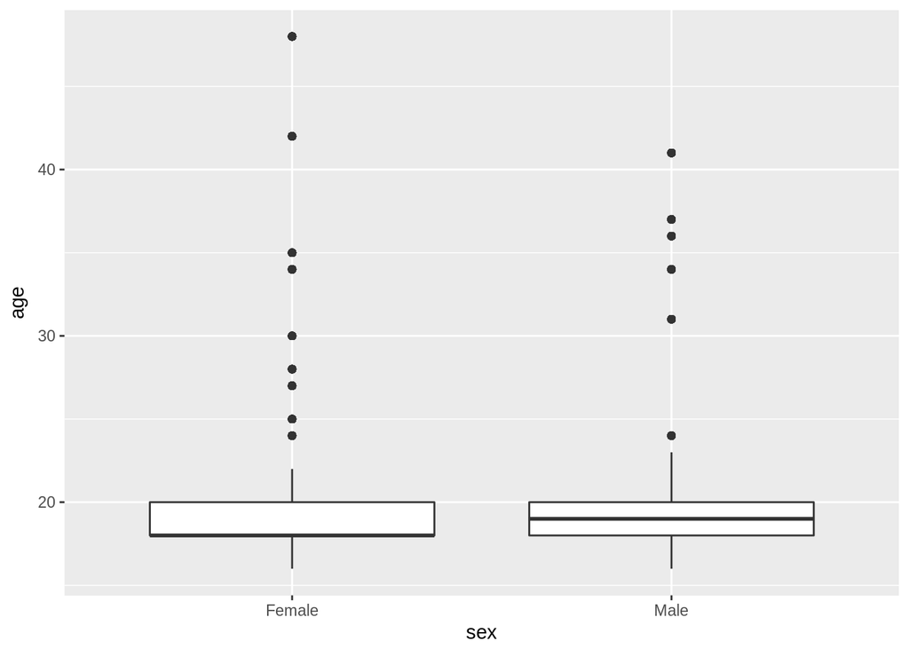

```r
ggplot(hiphop, aes(x = sex, y = age)) + geom_boxplot()
```

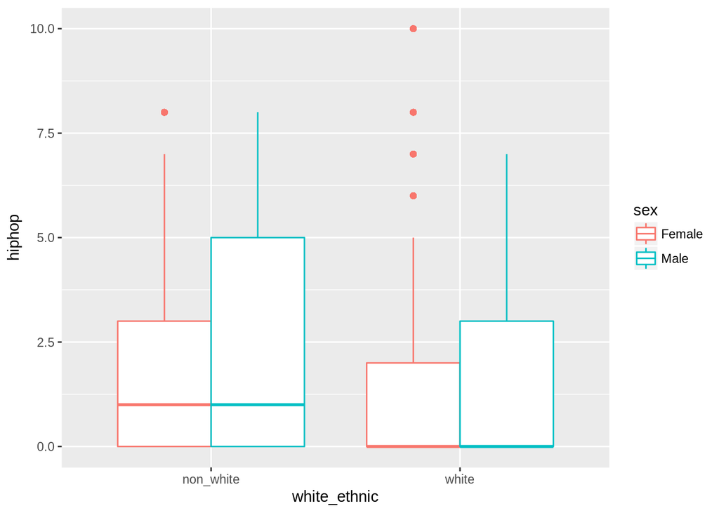

```r
ggplot(hiphop, aes(x = white_ethnic, y = hiphop, color = sex)) + geom_boxplot()
```

## Familiar Words

1. For each demographic group listed below, determine which word(s) in this study was the most and least familiar on average.
1. People below the age of 20

```r
below_20 <- hiphop %>%
  filter(age < 20) %>%
  group_by(word) %>%
  summarize(avg_familiarity = mean(familiarity))

below_20 %>%
  arrange(avg_familiarity) %>%
  top_n(3, avg_familiarity)
```

```
## # A tibble: 3 x 2
##   word         avg_familiarity
##   <fctr>                 <dbl>
## 1 hella                   3.73
## 2 feel me                 4.27
## 3 off the hook            4.42
```

```r
below_20 %>%
  arrange(desc(avg_familiarity)) %>%
  top_n(3, desc(avg_familiarity))
```

```
## # A tibble: 3 x 2
##   word             avg_familiarity
##   <fctr>                     <dbl>
## 1 The Nation                  1.04
## 2 domino                      1.03
## 3 catch the vapors            1.03
```

2. Non-white women

```r
non_white_women <- hiphop %>%
  filter(sex == "Female" & white_ethnic == "non_white") %>%
  group_by(word) %>%
  summarize(avg_familiarity = mean(familiarity))

non_white_women %>%
  top_n(3, avg_familiarity)
```

```
## # A tibble: 3 x 2
##   word         avg_familiarity
##   <fctr>                 <dbl>
## 1 boo                     3.77
## 2 feel me                 4.19
## 3 off the hook            3.54
```

```r
non_white_women %>%
  top_n(3, desc(avg_familiarity))
```

```
## # A tibble: 4 x 2
##   word              avg_familiarity
##   <fctr>                      <dbl>
## 1 break someone out            1.00
## 2 dukey rope                   1.00
## 3 plex                         1.00
## 4 rollie                       1.00
```

3. White men above the age of 30

```r
old_white_men <- hiphop %>%
  filter(sex == "Male" & white_ethnic == "white" & age > 30) %>%
  group_by(word) %>%
  summarize(avg_familiarity = mean(familiarity))

old_white_men %>%
  top_n(3, avg_familiarity)
```

```
## # A tibble: 3 x 2
##   word            avg_familiarity
##   <fctr>                    <dbl>
## 1 5-0                        4.20
## 2 dead presidents            3.60
## 3 feel me                    4.00
```

```r
old_white_men %>%
  top_n(3, desc(avg_familiarity))
```

```
## # A tibble: 25 x 2
##    word              avg_familiarity
##    <fctr>                      <dbl>
##  1 ay yo trip                   1.00
##  2 beezy                        1.00
##  3 break someone out            1.00
##  4 catch the vapors             1.00
##  5 crossroads                   1.00
##  6 crump                        1.00
##  7 dap                          1.00
##  8 dollar cab                   1.00
##  9 domino                       1.00
## 10 duckets                      1.00
## # ... with 15 more rows
```

## Use the Data

A former Canadian child TV star named Aubrey Graham is interested in switching careers to become a rapper. Aubrey hires you to consult the hiphop dataset to help compose his new songs.

1. Aubrey hopes that his songs will be percieved as authentically hiphop. He hopes his lyrics will be recognizeable to those who describe themselves as hiphop fans, but less recognizeable to those who do not consider themselves fans. Suggest some words or phrases that Aubrey should try to use, and some words he should avoid.

```r
hiphop_fans <- hiphop %>%
  filter(hiphop > 3) %>%
  group_by(word) %>%
  summarize(avg_fam = mean(familiarity))

hiphop_fans %>%
  top_n(3, avg_fam)
```

```
## # A tibble: 3 x 2
##   word         avg_fam
##   <fctr>         <dbl>
## 1 feel me         4.50
## 2 hella           4.31
## 3 off the hook    4.31
```

```r
hiphop_fans %>%
  top_n(3, desc(avg_fam))
```

```
## # A tibble: 3 x 2
##   word              avg_fam
##   <fctr>              <dbl>
## 1 break someone out    1.06
## 2 domino               1.06
## 3 The Nation           1.12
```

Aubrey should use words like “Feel me”, “Hella”, and “Off the Hook” but should avoid words “Break someone out”, “domino” and “the nation”.

2. Although Aubrey wants to be authentic, he also hopes to sell records, of course. Two titles have been suggested for his first album: “Hotline Boo” or “Hella Bling”. Based on the dataset, which will appeal more to the higher population areas? Make at least one plot to support your answer.

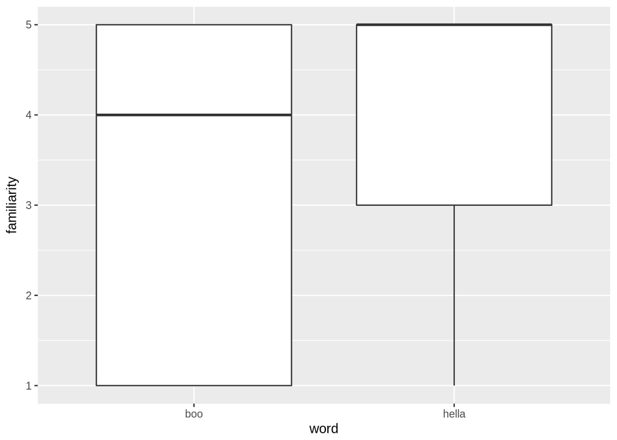

```r
county_avg <- mean(hiphop$county)
city_avg <- mean(hiphop$city)
high_pop_areas <- hiphop  %>%
  filter(county > county_avg | city > city_avg) %>%
  filter(word == "hella" | word == "boo" | word == "Hotline" | word == "Bling")
high_pop_areas %>%
  ggplot(aes(x = word, y = familiarity)) + geom_boxplot()
```

3. Aubrey’s true life dream is to collaborate with his fellow Canadian musician Justin Bieber. Luckily, he knows that Bieber himself was one of the subjects in this study! You know that Bieber is a white male, aged 17-23 at the time of the study, from a relatively small town (10,000-60,000 people) in Ontario.
- Determine which subject is secretly Bieber, and justify your answer.
- Then suggest a track listing (11 song titles) for Aubrey’s album collaboration with the Biebs.

```r
jb <- hiphop %>%
  filter(white_ethnic == "white") %>%
  filter(sex == "Male") %>%
  filter(age >= 17 & age <= 23) %>%
  filter(city >= 10000 & city <= 60000)

jb %>%
  group_by(subj) %>%
  summarize(biebs = max(bieber)) %>%
  top_n(1, biebs)
```

```
## # A tibble: 1 x 2
##   subj   biebs
##   <fctr> <dbl>
## 1 p17     5.00
```

Based on the demographic and the beiber knowledge, Justin Beiber is subject p17.

```r
jb %>%
  group_by(word) %>%
  summarize(avg_fam = mean(familiarity)) %>%
  #top_n(20, (avg_fam))
  arrange(avg_fam)
```

```
## # A tibble: 64 x 2
##    word             avg_fam
##    <fctr>             <dbl>
##  1 catch the vapors    1.00
##  2 CP time             1.00
##  3 dollar cab          1.00
##  4 face gator          1.00
##  5 humming             1.00
##  6 rollie              1.00
##  7 saditty             1.00
##  8 sweatbox            1.00
##  9 trill               1.00
## 10 ay yo trip          1.07
## # ... with 54 more rows
```

In tribute to his background, I would suggest words with the top familiarity from his demographic. Thus, with my excellent music and marketing skills, I would choose their track list to be: 1. Off The Hook 2. Make it Rain 3. Fell me 4. Ashy Beiber (Ashley Beiber) 5. 5-0 A-town 6. Dead Presidents 7. Finna boo 8. What it is? 9. Ballin’ Facheezie 10. What it do 11. Hella Straight Cash